# A day in the life of Github’s Timeline

by: “Sebastian Ibarguen” @sebasibarguen

## Abstract

This short analysis looks at how public collaboration happens in Github. The study focuses on *PushEvents* which are the atomic blocks of contribution. The primary interest is to better understand the relationhip’s collaboration by the repository features **in a given day** in Github.

## Introduction

*[“GitHub is the best place to share code with friends, co-workers, classmates, and complete strangers. Over seven million people use GitHub to build amazing things together.”](https://github.com/about)*

It is now the biggest code host and is huge in the open-source community. The new workflows and collaborations models have changed the ease, simplicity and automation of creating software.

In this study we are interested in the public projects hosting, specifically *PushEvent*. Github’s API gives us all the public events happening in their [timeline](https://developer.github.com/v3/activity/events/). This study uses the Github Archive dataset, which is a compilation of the Github timeline. The data format is a JSON stream, which is given in a Gzip file and is aggregated in an hourly basis.

Given the size of the dataset, I took just one day, November 1, 2014. (In the extra section I explored using BigQUery to analyze years of data which would of been imposible to do it locally because of the size of the dataset). Arguably *PushEvent* represents the most important event when analyzing collaboration. A *PushEvent* in simple terms is a (small) code contribution to a project, and it is comprised of *git commits*.

## Preparing the data

As mentioned before, the data from Github Archive is a JSON stream of all Githubs public events. There are [25 different types of events](https://developer.github.com/v3/activity/events/types/), ranging from *DownloadEvent*, *IssueEvent* to *StatusEvent*.

The output file is 735MB, it contains 159,102 observations or PushEvents. What follows is the python script.

```python
import gzip
import urllib
import json

# List of filenames for 24 hours of November 1, 2014.
filenames = ["2014-11-01-" + str(i) + ".json.gz" for i in range(1,24)]

# Open output file
with open('data/2014-11-01-PushEvent.json', 'wb') as f:

    # Download files
    for filename in filenames:
        url = base_url + filename

        print "Starting to download: " + url
        f_name, f_headers = urllib.urlretrieve(url)
        print "Finished download."

        with gzip.open(f_name) as g:
            content = g.readlines()

            for line in content:
                event = json.loads(line)

                if event["type"] == "PushEvent":
                    f.write(line)
        print "Finished writing: " + filename
```

After running the python script, the data file is still a json stream, but the big difference is that it’s of the same type of event and therefore the same json scheme. The json file can be [downloaded from this link](http://storage.googleapis.com/udacity-nanodegree-visualization/2014-11-01-PushEvent-2.json). In R we then read the data and pass it to a dataframe. The newly created dataframe is still in a weird format because it has dataframes inside of dataframes, in a way copying what the initial json scheme. To better clean the data, a new dataframe is created with the variables of interest and in the same level. We then delete the old dataframe to free up memory.

```r
# Import all libraries
suppressMessages(library(jsonlite))
suppressMessages(library(ggplot2))
suppressMessages(library(dplyr))
suppressMessages(library(maps))
suppressMessages(library(GGally))
```

```r
# Read preprocessed json file. It gives a mixture of columns with values and columns with
# dataframes inside.
github = stream_in(file("data/2014-11-01-PushEvent-2.json"), verbose=FALSE)

# Build a new dataframe from the features of interest. We build this so
# that all values from features are in the same level.
df = data.frame(language = github$repository$language,
                payloadSize = github$payload$size,
                user = github$actor_attributes$email,
                location = github$actor_attributes$location,
                url = github$repository$url,
                date = github$repository$created_at,
                pushDate = github$created_at,
                fork = github$repository$fork,
                size = github$repository$size,
                forks_count = github$repository$forks_count,
                open_issues = github$repository$open_issues_count,
                watchers_count = github$repository$watchers_count,
                stargazers_count = github$repository$stargazers_count)

# We delete the initial github dataframe to free up memory.
rm(github)
```

With the data ready, we can start doing the cool stuff =)

## Exploring the data

### Understanding the data

Here I will give a brief description of all the variables that are of interest in this research. If you need to learn more about git, github and code collaboration concepts, I suggest the following reading: [Github Glossary](https://help.github.com/articles/github-glossary).

| Variable | Description | More info |
| --- | --- | --- |
| Commit | An individual change to a file or files saved with specific id | https://help.github.com/articles/github-glossary/#commit |
| Push | Sending local commits to remote repository | [Push](https://help.github.com/articles/github-glossary/#push) |
| Forks | A copy of a repository to another user | [Github Fork](https://help.github.com/articles/fork-a-repo/) |
| Open Issues | Issues presented by users, like bugs or improvements | [Issue’s](https://help.github.com/articles/github-glossary/#issue) |
| StarGazer’s | Count of users that have starred a public repository to follow updates | [Github Stars](https://help.github.com/articles/about-stars/) |

### How much work per push?

How much is the work load per push event? In other words, do coders wait a long time to push, or do the push when they have a small amount of commits?

```
## stat_bin: binwidth defaulted to range/30. Use 'binwidth = x' to adjust this.
```

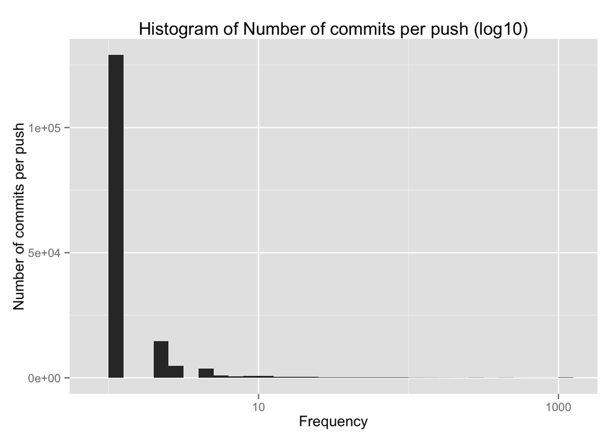

```r
# We use the ggplot function, and scale x to log for better visualization.
ggplot(df, aes(payloadSize)) +
  geom_histogram() +
  scale_x_log10() +
  ggtitle("Histogram of Number of commits per push (log10)") +
  xlab("Frequency") +
  ylab("Number of commits per push")
```

Even when scaled be log, the frequency of commits is small per push event.

### Collaboration in general

In Github, there are two types of collaborations possible, bug reporting (discussions) or code contribution. Both play major roles in open source software. In the dataset, bug reporting is measured via open issues and code contributions is measured via fork count.

So let’s take a loot at the bug reporting histogram.

```
## stat_bin: binwidth defaulted to range/30. Use 'binwidth = x' to adjust this.
```

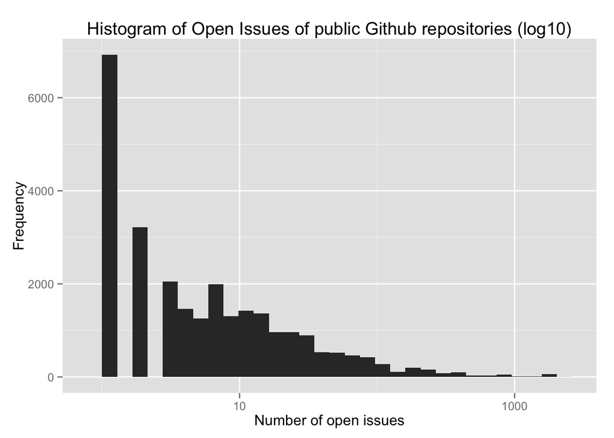

```r
ggplot(df, aes(open_issues)) +
  geom_histogram() +
  scale_x_log10() +
  ggtitle("Histogram of Open Issues of public Github repositories (log10)") +
  xlab("Number of open issues") +
  ylab("Frequency")
```

The x variable was transformed using logarithm scale, *it seems that there are few projects with a lot of open issues, and a lot with few or none*.

Now lets look at code contributions.

```
## stat_bin: binwidth defaulted to range/30. Use 'binwidth = x' to adjust this.
```

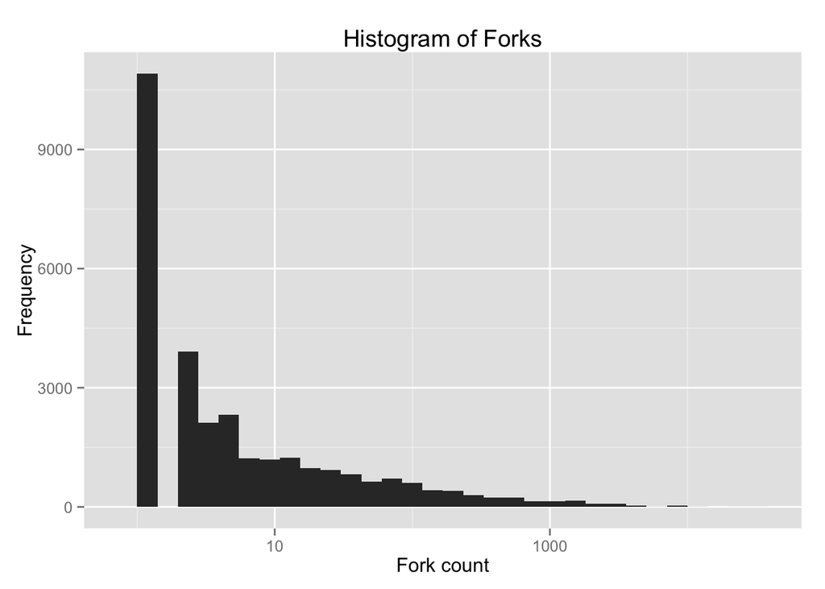

```r
ggplot(df, aes(forks_count)) +
  geom_histogram() +
  scale_x_log10() +
  ggtitle("Histogram of Forks") +
  xlab("Fork count") +
  ylab("Frequency")
```

Fork counts seem to follow the same pattern as open issues. Makes a lot of sense because both represent a type of collaboration.

### Complexity and collaboration

The size of a repository indirectly measures the complexity of a project. The reasoning goes as follows: bigger size means more bytes which (almost always) translates into more lines of code and/or more files which consequently increases the amount of information needed to process and understand the project, therefore it increases its complexity.

Do more complex projects have more collaboration (measured via forks)? We can theorize that more complex projects are more easily undertaken by bigger teams with more collaborators. On the other side, smaller projects are easier to understand and therefore have a lower barrier to entry for new collaborators.

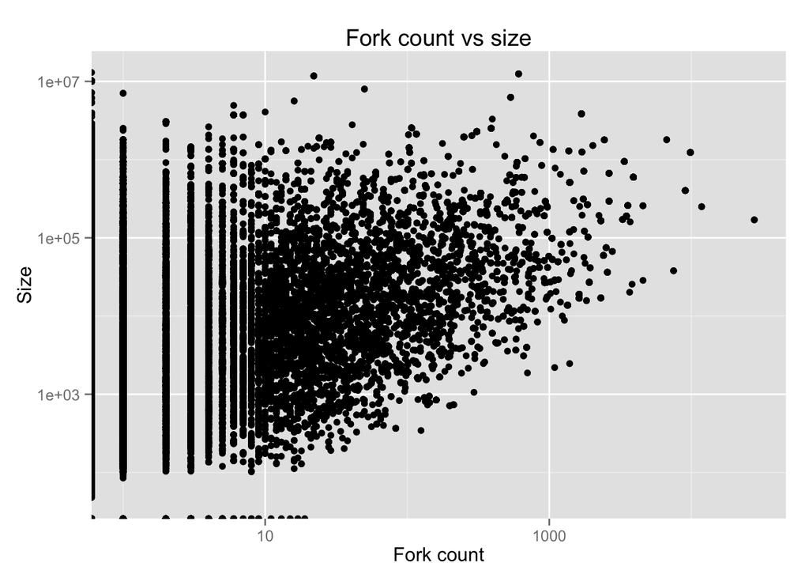

```r
ggplot(df, aes(forks_count, size)) +
  geom_point() +
  scale_x_log10() +
  scale_y_log10() +
  xlab("Fork count") +
  ylab("Size")  +
  ggtitle("Fork count vs size")
```

The opposing forces seem to even out somewhat. There is a weak relationship between size and fork counts.

What if we take the ratio between size and fork count? Should there be any pattern in complexity per contributor?

```
## stat_bin: binwidth defaulted to range/30. Use 'binwidth = x' to adjust this.
```

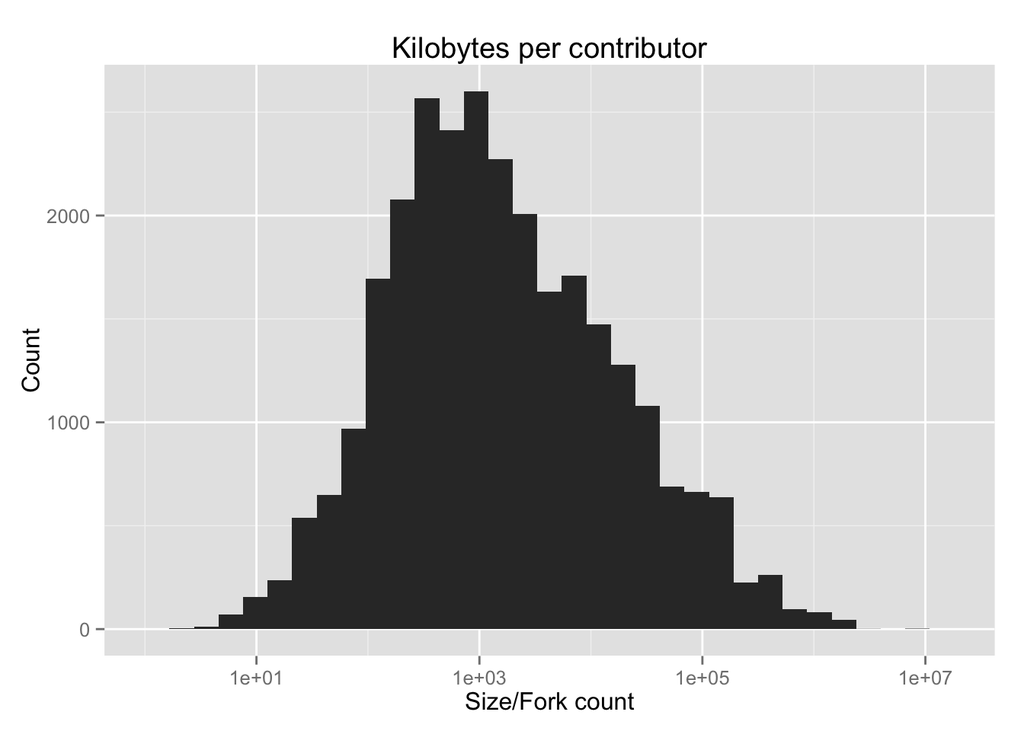

```r
# Plot size over forks count.
ggplot(df, aes(size/forks_count)) +
  geom_histogram() +
  scale_x_log10() +
  xlab("Size/Fork count") +
  ylab("Count")  +
  ggtitle("Kilobytes per contributor")
```

### Coding through the day

Are there certain hours of the day where more push events occur?

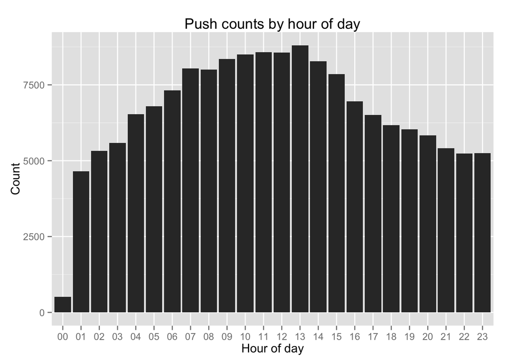

```r
# Must first create datetime object from string, then get the hour variable out.
df$hourOfDay = lapply(df$pushDate, strptime, format="%Y-%m-%dT%H:%M:%S")
df$hourOfDay = lapply(df$hourOfDay, strftime, format="%H")

df$pushHour = sapply(df$hourOfDay, function(x) { return( x[[1]] ) })

ggplot(df, aes(pushHour)) +
  geom_histogram(binwidth=1) +
  xlab("Hour of day") + ylab("Count")  +
  ggtitle("Push counts by hour of day")
```

Coders tend to push more around 12pm and follow a normal distribution curve around that mean. Although there appears to be a steady and more stable rise from 7am till 12pm-13pm, and then the push counts tend to level down more steeply (although not by that much).

Now that we are on looking for patterns with time, it might be interesting to see how old are the repositories and if there is a relationship between repository age and forks.

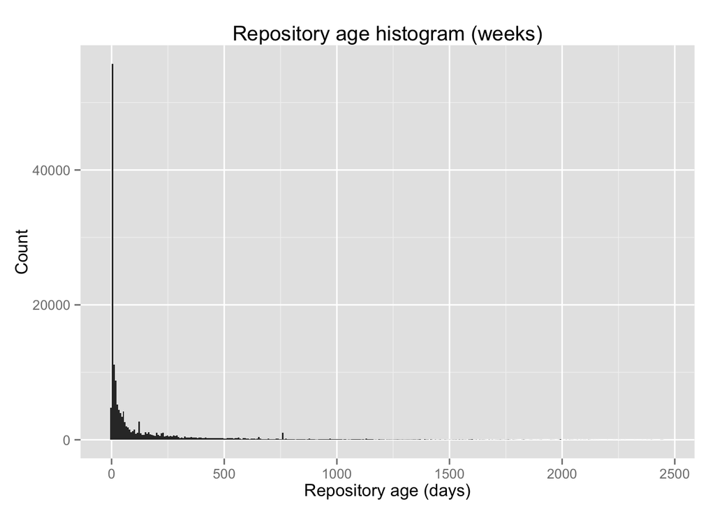

```r
# Get the difference between each date and November 1, 2014
df$age = as.Date(df$date) %>%
         difftime(as.Date("2014-11-01"), units="days") %>%
         as.numeric

# Get a histogram grouped by 7 or weekly.
ggplot(df, aes(-age)) +
  geom_histogram(binwidth=7) +
  xlab("Repository age (days)") +
  ylab("Count")  +
  ggtitle("Repository age histogram (weeks)")
```

Wow, there are a lot of very young repositories and exponentially fewer older ones. Transforming the age by a logarithmic scale should help us visualize it better.

```
## stat_bin: binwidth defaulted to range/30. Use 'binwidth = x' to adjust this.
```

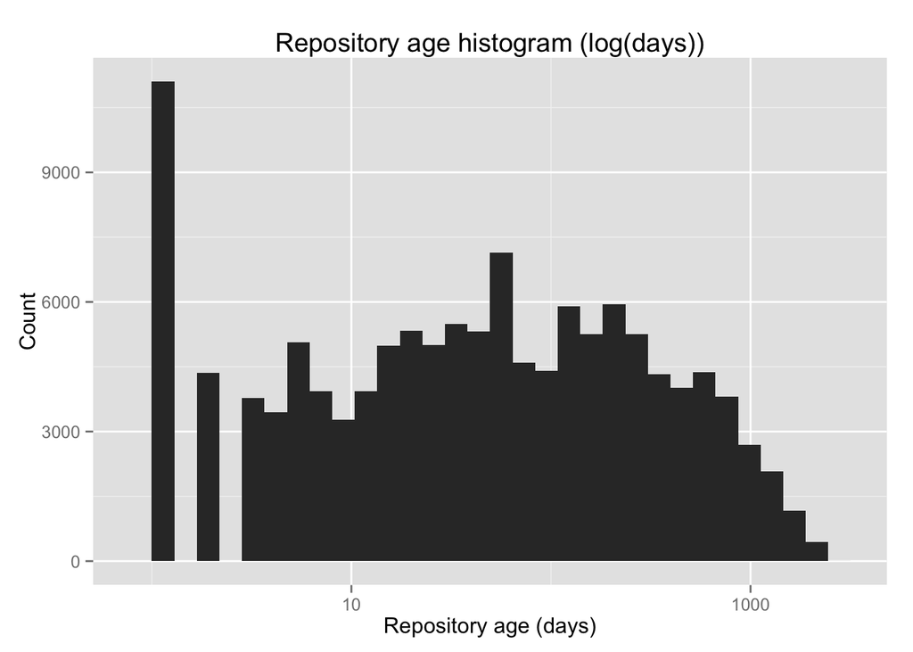

```r
# Plot the age histogram scaling the x by log
ggplot(df, aes(-age )) +
  geom_histogram()  +
  scale_x_log10() +
  xlab("Repository age (days)") +
  ylab("Count")  +
  ggtitle("Repository age histogram (log(days))")
```

This plot is quite interesting, there is a clear peak in new repositories, then there is a drop and it steadily rises again. This might indicate there are different types of repositories that coders use. For example there are short term repositories where I might just upload my Udacity project and not commit new code to it in a long time, then there are longer term projects like Twitter Bootstrap.

[figure not shown]

```r
# Subsetting the data to remove clutter in lower values for fork counts.
ggplot(subset(df, forks_count > 10),
       aes(-age, forks_count, size = stargazers_count)) +
  geom_point() + scale_x_log10() +
  scale_y_log10() +
  ggtitle("Fork count vs Age") +
  xlim("Age") +
  ylim("Fork count")
```

## Where in the world are the coders?

What countries are most active?

To do a good geographic analysis, first I had to get the latitude and longitude of all the locations. For that I used the [Unlock API](http://edina.ac.uk/unlock/places/api.html) following the suggestion of [this website](http://geography.oii.ox.ac.uk/?page=github). I also took inspiration from a fellow [Udacitian’s example project](https://s3.amazonaws.com/udacity-hosted-downloads/ud651/GeographyOfAmericanMusic.html). Given the time that it takes to run on all 6068 locations, I wrote the df.location dataframe with the lat-long values into a csv file so it would take less time to read.

```
df.location = group_by(df, location) %>%
              summarise(pushes=n(),
                        total = sum(payloadSize, na.rm=TRUE)
                        )
df.location$location = tolower(df.location$location)

df.location$centroid = NA
df.location$country = NA

for(i in 1:length(df.location$location)) {

  if( nchar(df.location$location[i]) <= 3 ){
    df.location$centroid[i] = NA
    next
  }

  url = paste("http://unlock.edina.ac.uk/ws/search?format=json&name=",
              URLencode(df.location$location[i]),
              sep="")
  good_url_call = 1
  tryCatch({
    json = fromJSON(url)
    }, error = function(e){
      good_url_call = 0
    })

  if (!good_url_call) { next }

  if ( as.numeric(json$totalResults) > 0 ) {

    df.location$centroid[i] = json$features$properties$centroid[1]
    df.location$country[i] = json$features$properties$country[1]

  }
}

latlon = strsplit(df.location$centroid, ",")
df.location$lat = sapply(latlon, function(x){ return(as.numeric(x[2])) })
df.location$lon = sapply(latlon, function(x){ return(as.numeric(x[1])) })

write.csv(df.location, "data/github_location.csv")
```

So reading the file, and the first thing to do is just plot the latitude and longitude.

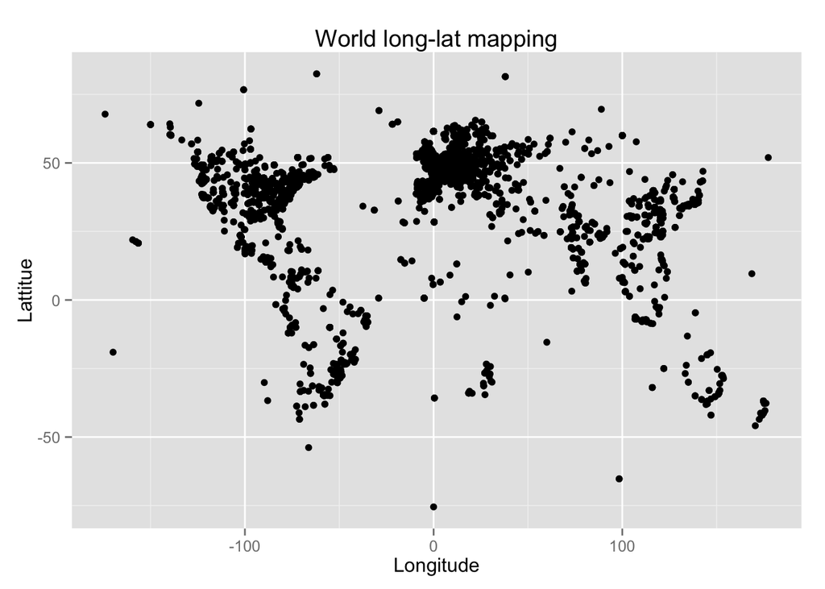

```r
df.location = read.csv("data/github_location.csv")

ggplot(df.location, aes(lon, lat)) +
  geom_point() +
  xlab("Longitude") +
  ylab("Lattitue")  +
  ggtitle("World long-lat mapping")
```

The plot is pretty cool, even though we don’t have a map behind it, we can clearly see the continents and North America, South America and Europe with huge activity. Of the 6068 possible locations, there were 2022 missing or unable to identify. Given that the missing data is about a third of the dataset, the data probably is not a good statistical representation of the Github community because of self-selection. It wouldn’t be unreasonable to suspect that more people from countrys of the likes of China tend not to list their countrys when compared to the US for example.

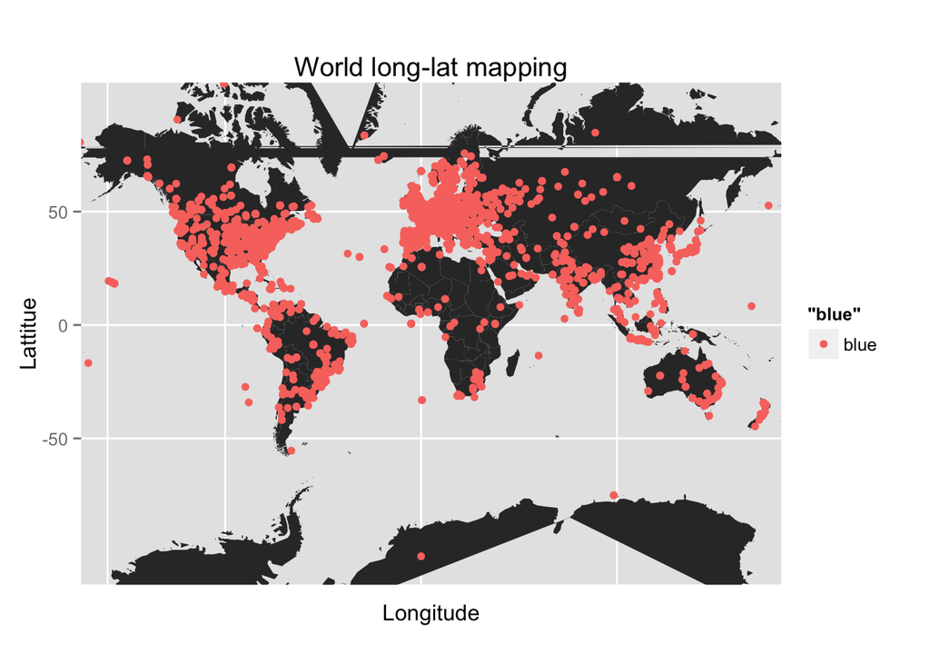

```r
# Import world data from map library.
map = map_data("world")

# Plot the map, and on top of it plot the locations of github contributors.
ggplot(map, aes(x = long, y = lat, group = group)) +
  geom_polygon() +
  coord_map() +
  geom_jitter(data = df.location, aes(lon, lat, colour="blue", group=NULL)) +
  xlab("Longitude") +
  ylab("Lattitue")  +
  ggtitle("World long-lat mapping")
```

When we group the data by country, we see that most push events come from the US and then european countries plus Canada.

```r
# Create new dataframe by grouping points by country.
df.country = group_by( df.location, country) %>%
             summarise( pushes = sum(total), lat = mean(lat), lon = mean(lon))

df.country = df.country[order(-df.country$pushes),]

head(df.country)
```

```
## Source: local data frame [6 x 4]
##
##         country pushes      lat        lon
## 1            NA 427522       NA         NA
## 2 United States  38314 38.42838 -91.611183
## 3         Spain  28401 40.02148  -3.361659
## 4       Germany  24936 50.69026   9.654749
## 5        Canada  15591 51.08399 -93.502474
## 6        France  13676 43.66063   2.095132
```

### Programming languages

Do coders of certain languages tend to be more collaborative?

To facilitate the analyses, a new dataframe is created by grouping the original dataframe by languages.

```r
# Build new dataframe by grouping data by programming language.
df.language = group_by(df, language) %>%
              summarise(pushes = n(),
                        open_issues = sum(open_issues),
                        open_issuesA = mean(open_issues),
                        open_issuesSD = sd(open_issues),
                        forks = sum(forks_count),
                        forksA = mean(forks_count),
                        forksSD = sd(forks_count),
                        size = sum(as.numeric(size)),
                        watchers = sum(watchers_count),
                        stars = sum(stargazers_count),
                        age = mean(age)
                )
df.language$language = factor(df.language$language)
```

To first get an idea of the relationships between languages and their features, lets get a correlation grid:

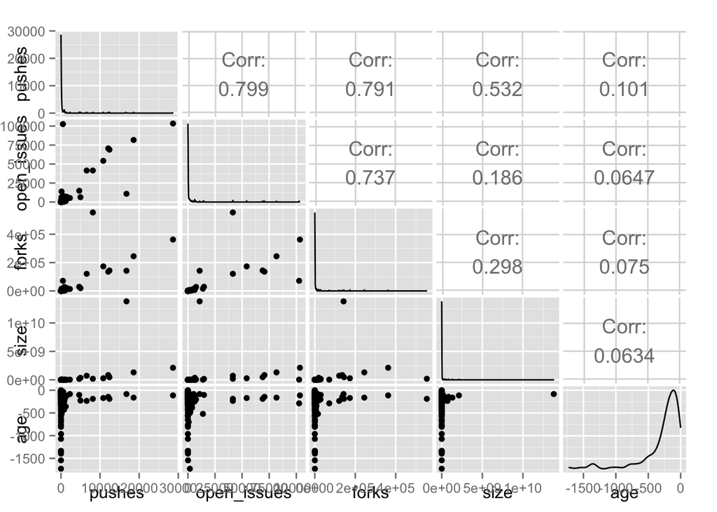

```r
# Use GGPair library to plot relationships between features.
ggpairs(subset(df.language, select=c(pushes, open_issues, forks, size, age)))
```

The correlation between open issues and forks is clearly marked at 0.737, as well a the correlation between the number of push events and for a certain language and the number of open issues and forks. This last relationship is interesting, and makes sense. Coders who tends to be more active using Github will probably tend to be more active in other activities like forks and opening issues. Another interesting note is that *bigger does not mean more collaboration*. The reasons behind this might be that a bigger project is more daunting to understand and therefore more costly for people to collaborate to.

This takes us to the next plots, to better see the correlation. Collaboration, as we’ve discussed can occur on two levels code contribution and bug reporting. Is there a clear linear relationship between the two? I subsetted the dataframe by langue, including only repositories with at least one fork and at least one open issue. This is to eliminate a huge chunk of repositories that are public in Github, but really don’t have any collaboration going on.

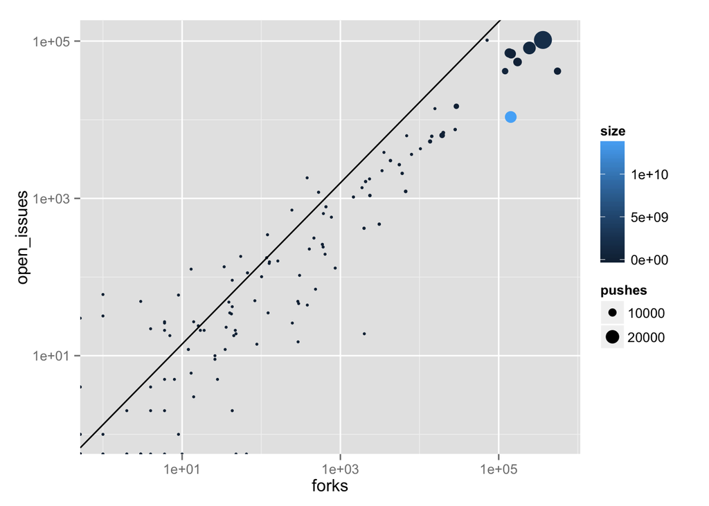

```r
# Save the coefficients of correlations. Subset the data so we get only repositories with at least
# one fork and at least one open issue.
model = coef(lm(log10(forks) ~ log10(open_issues),
                data = subset(df.language, forks > 0 & open_issues > 0)))

#
ggplot(df.language, aes(forks, open_issues)) +
  geom_point(aes(size = pushes, colour = size)) +
  scale_x_log10() + scale_y_log10() +
  geom_abline(intercept = model[[1]], slope = model[[2]])
```

#### Age and language

Is there a relationship between the age of a repository and specific programming languages?

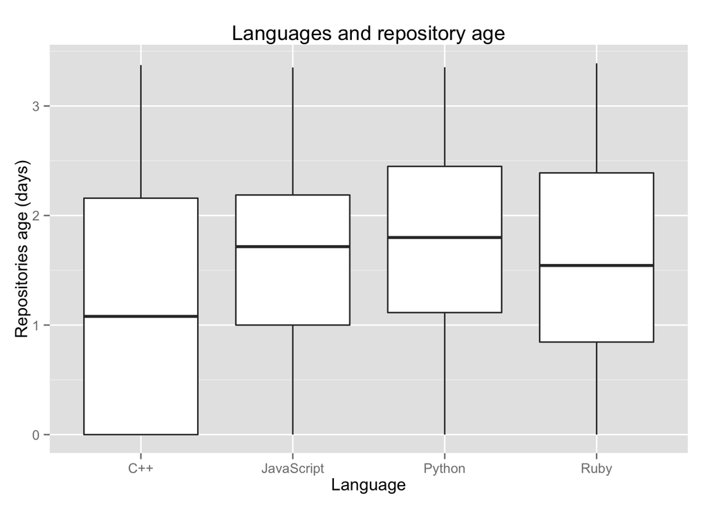

```r
# Have full access to the data set, but only select the most popular languages to improve the graphs visualization.
df.subsetLanguages = subset(df, df$language == "Python"|
                                df$language == "Ruby" |
                                df$language == "JavaScript" |
                                df$language == "C++")

#
ggplot(df.subsetLanguages, aes(language, log10(-age))) +
  geom_boxplot()+
  xlab("Language") +
  ylab("Repositories age (days)")  +
  ggtitle("Languages and repository age")
```

#### Top 10 languages

Given that there are 143 programming languages, the visualizations can get cluttered up. It’s more interesting to see which are the top 10 languages, and how do they compare with one another. For these graphs we use a different dataframe witch only takes in the top 10 languages and removes the NA value in the 4 column.

```r
# Here we select the top 10 languages and remove the NA's row. First line orders the dataframe
# by push count, then we remove the NA row, finally we select the top 10 rows from the dataframe.
df.top_languages = df.language[order(-df.language$pushes),]
df.top_languages = df.top_languages[-c(4),]
df.top_languages = df.top_languages[seq(1,10),]

head(df.top_languages)
```

```
## Source: local data frame [6 x 12]
##
##     language pushes open_issues open_issuesA open_issuesSD  forks
## 1 JavaScript  28653      103324       103324            NA 362522
## 2       Java  18578       81706        81706            NA 244623
## 3        CSS  16753       10832        10832            NA 142096
## 4     Python  12396       68959        68959            NA 143993
## 5        C++  12093       70611        70611            NA 135772
## 6        PHP  10825       54223        54223            NA 173199
## Variables not shown: forksA (dbl), forksSD (dbl), size (dbl), watchers
##   (int), stars (int), age (dbl)
```

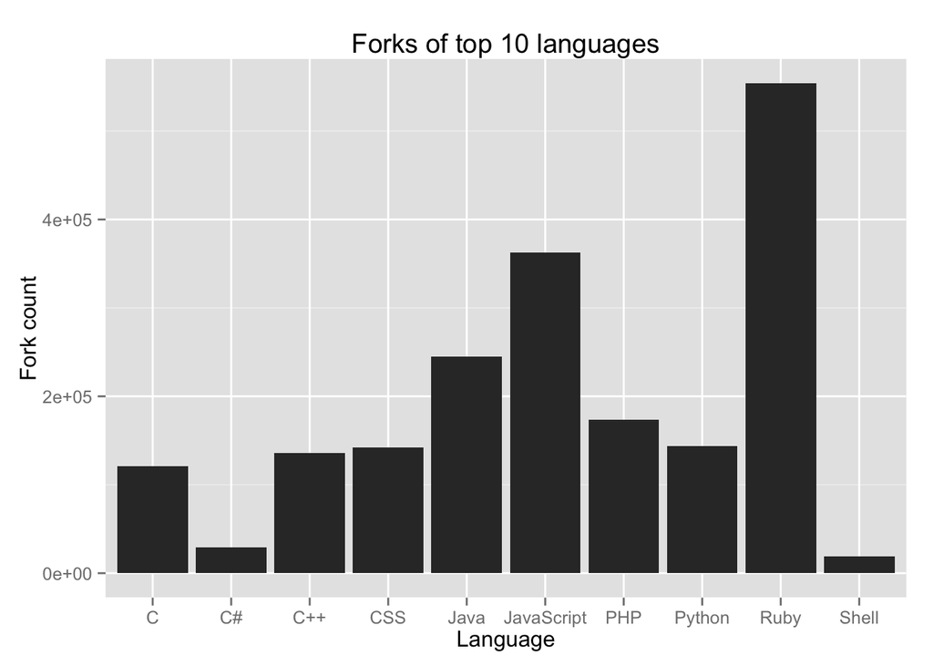

```r
ggplot(df.top_languages, aes(language, forks)) +
  geom_bar(stat="identity") +
  xlab("Language") +
  ylab("Fork count") +
  ggtitle("Forks of top 10 languages")
```

Taking the analysis another step, we can see if there is a relationship between the amount of open issues, forks and the number of push events.

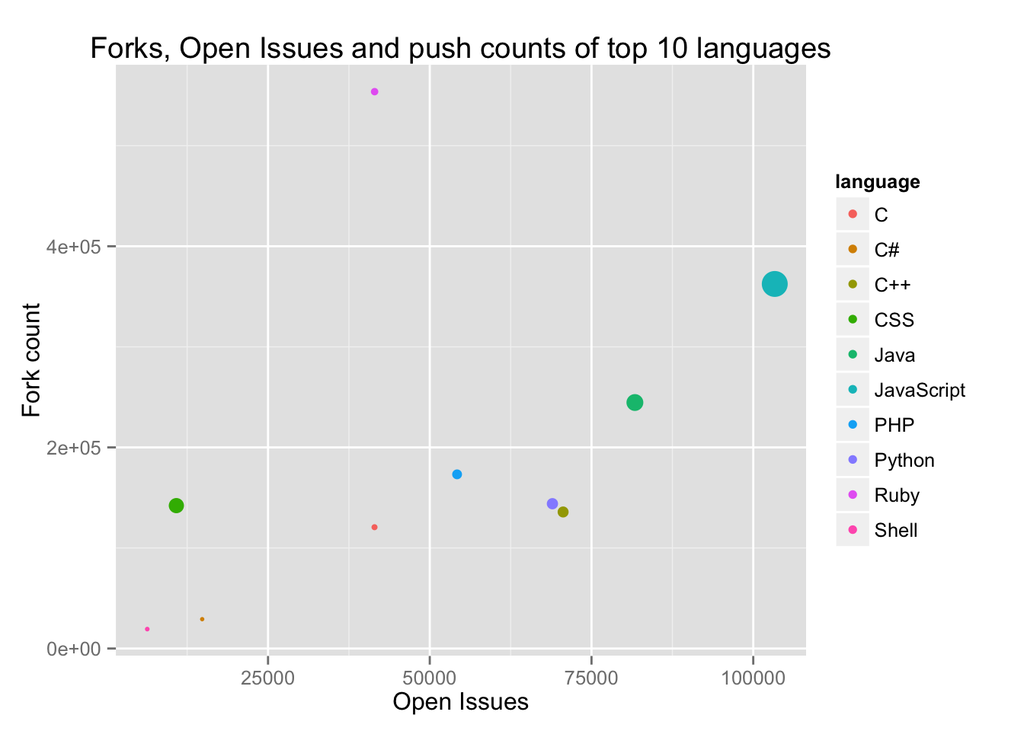

```r
ggplot(df.top_languages,
       aes(open_issues, forks, size=pushes, colour=language)) +
  geom_point() +
  guides(size=FALSE) +
  xlab("Open Issues") +
  ylab("Fork count") +
  ggtitle("Forks, Open Issues and push counts of top 10 languages")
```

### Having fun with Google BigQuery. Udacity promoting Github usage?

Just for fun, well take the BigQuery database for a spin. [Google hosts the whole Github Archive in Big Query](http://googledevelopers.blogspot.com/2012/05/using-google-bigquery-to-learn-from.html). This gives the potential to analyze the whole dataset and not limit to one event in one day, like this research did. I ran the following query to get all the repositories that mention Udacity either in the name or description of the repository, to see the amount of activity that Udacity generates on Github.

```sql
SELECT repository_language,
       repository_name,
       repository_description,
       LEFT (
         FORMAT_UTC_USEC(
           UTC_USEC_TO_DAY(
             PARSE_UTC_USEC(created_at))
             ),
          7) as month,
       COUNT(*) as pushes,
       SUM(payload_size) as commits,
       SUM(repository_forks) as forks,
       SUM(repository_watchers) as watchers,
       SUM(repository_open_issues) as open_issues,
       SUM(repository_size) as size
FROM (
  TABLE_QUERY([githubarchive:month],
    'REGEXP_MATCH(table_id, r"^201[1-4]\d\d")'
  ))
WHERE type = 'PushEvent'
AND (REGEXP_MATCH(repository_name,r'[^aA](u|U)dacity'))
OR (REGEXP_MATCH(repository_description,r'[^aA](u|U)dacity'))
GROUP BY month, repository_language, repository_name, repository_description
LIMIT 10000
```

With the csv file output, we can now find out how many repositories that mention Udacity have created push events from 2011 to 2014?

```r
# Import zoo module to use the as.yearmon function.
library(zoo)
```

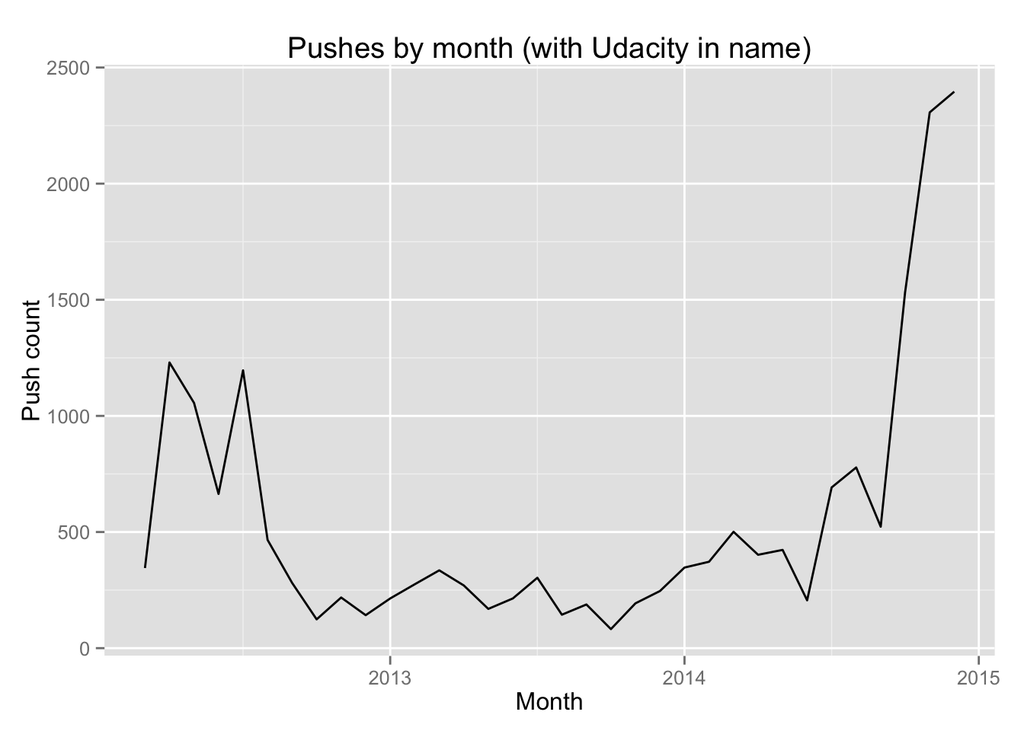

```r
bigquery = read.csv("data/results-20150123-183042.csv")
bigquery$date = sapply(bigquery$month, as.yearmon)

# Group data by date
bigquery.byMonth = group_by(bigquery, date) %>%
                   summarise(forks = sum(forks), pushes = sum(pushes))

# Plot
ggplot(bigquery.byMonth, aes(date, pushes)) +
  geom_line() +
  xlab("Month") +
  ylab("Push count")  +
  ggtitle("Pushes by month (with Udacity in name)")
```

Udacity is clearly promoting a lot of more code pushing to Github since mid 2014.

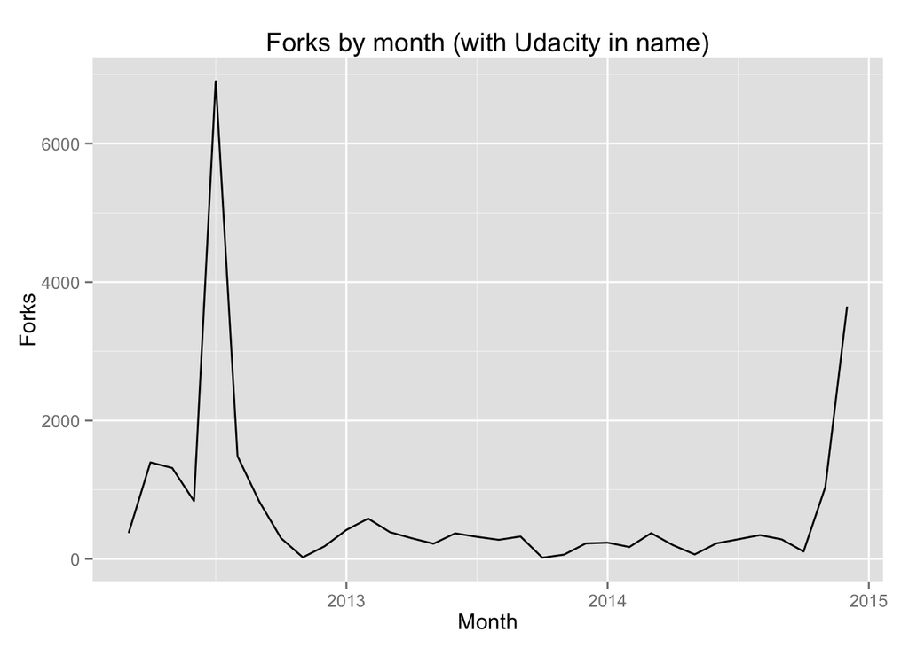

```r
ggplot(bigquery.byMonth, aes(date, forks)) +
  geom_line() +
  xlab("Month") +
  ylab("Forks")  +
  ggtitle("Forks by month (with Udacity in name)")
```

## Final Plots and Summary

In this research I detailed my train of thought and process of going through Githubs dataset. For the final plots I will repeat my favourite three, which I believe are most insightful.

[figure not shown]

```r
ggplot(map, aes(x=long, y=lat, group=group)) +
  geom_polygon() +
  coord_map() +
  geom_jitter(data=df.location, aes(lon, lat, colour="blue", group=NULL)) +
  xlab("Longitud") +
  ylab("Lattitude")  +
  ggtitle("Forks by month (with Udacity in name)")
```

This plot shows the geographic diversity, dispersion and concentration of code contribution that happend in Github every single day. It’s really a global phenomena, but still dominated by developed countries.

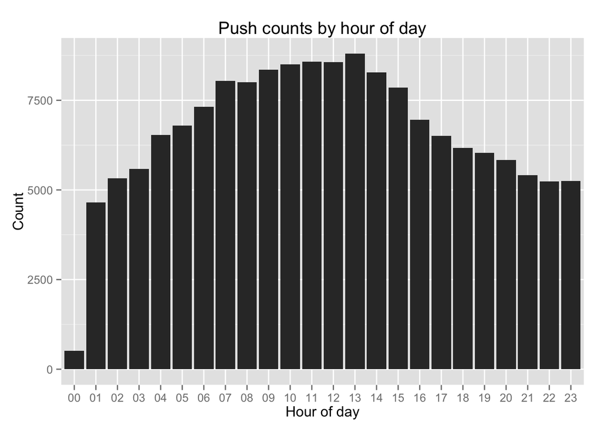

```r
ggplot(df, aes(pushHour)) +
  geom_histogram(binwidth=1) +
  xlab("Hour of day") +
  ylab("Count")  +
  ggtitle("Push counts by hour of day")
```

This might not be so surprising, but it does hint that code contribution happens during office hours, it probably is work!

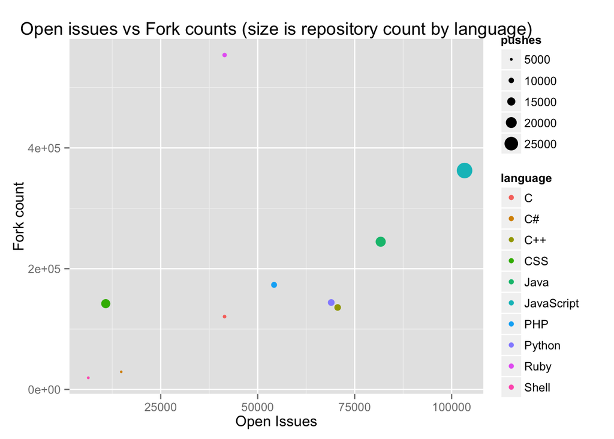

```r
ggplot(df.top_languages,
       aes(open_issues, forks, size=pushes, colour=language)) +
  geom_point() +
  xlab("Open Issues") +
  ylab("Fork count") +
  ggtitle("Open issues vs Fork counts (size is repository count by language)")
```

Finally, this last plot is dense and shows a lot of information about language popularity in Github. The bigger the dot, the more push events that language had. There are various scripting languages like Ruby and JavaScript which show the most collaboration, but also C based languages.

## Reflection

In general, the research showed that most collaboration coders comes from US and Europe, that write in Ruby, JavaScript, Java and Python and push code around 12pm. A more complex project does not translate into more collaboration, but probably deeper collaboration. There is a strong feedback loop for successful projects that seem to attract more collaboration and therefore become successful. This is why fork counts and open issues follow an exponential relation instead of a linear.

A more in-depth analyses would take the whole Github timeline dataset. Using the whole dataset would open up a lot of cooler analyses. Given that this research only took in 1 day, there are risks of sampling error.